# Imputation of Longitudinal or Multi-level Data

## Preface

### R packages

In this practical, a number of R packages are used. If any of them are not installed you may be able to follow the practical but will not be able to run all of the code. The packages used (with versions that were used to generate the solutions) are:

- R version 3.6.1 (2019-07-05)
- `mice` (version: 3.6.0)
- `nlme` (version: 3.1.140)
- `JointAI` (version: 0.6.0)
- `splines` (version: 3.6.1)
- `ggplot2` (version: 3.2.1)

### Dataset

In this practical we will work with data from a trial on primary biliary cirrhosis (PBC) of the liver.

To get the **pbclong** data, load the file `pbclong.RData`. You can download it [here](https://nerler.github.io/EP16_Multiple_Imputation/practical/data/index.html). To load this dataset, you can use the command `file.choose()` which opens the explorer and allows you to navigate to the location of the downloaded file on your computer. If you know the path to the file, you can also use `load("<path>/<pbclong.RData")`.

The variables contained in the dataset `pbclong` are:

| `id` | patient identifier |
| --- | --- |
| `day` | continuously measured day of follow-up time (the time variable) |
| `sex` | patients’ sex (f: female, m: male) |
| `trt` | treatment group (0: D-penicillmain, 1: placebo) |
| `age` | patients’ age at intake |
| `ascites` | presence of ascites at baseline (0:no, 1:yes) |
| `hepato` | presence of hepatomegaly or enlarged liver |
| `bili` | serum bilirubin level at baseline |
| `copper` | urine copper (ug/day) |
| `albumin` | serum albumin level at follow-up (time-varying) |

The variables have the following distributions and proportions of missing values:

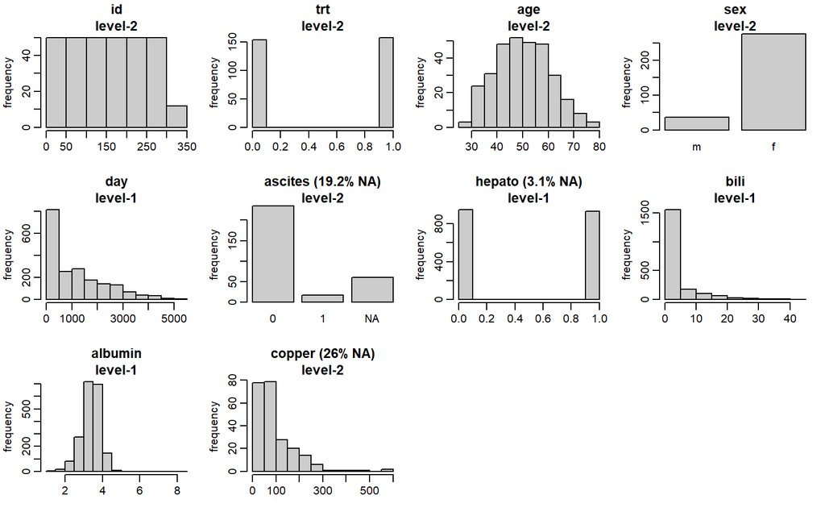

The missing data pattern is:

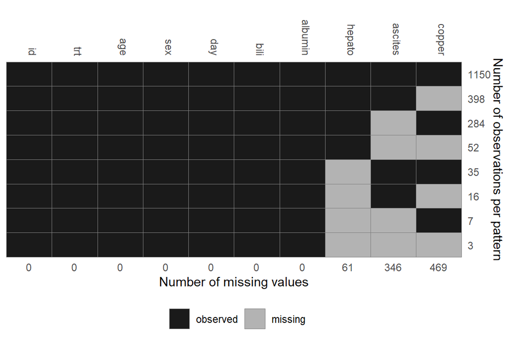

The longitudinal outcome `albumin` shows relatively linear trajectories over time:

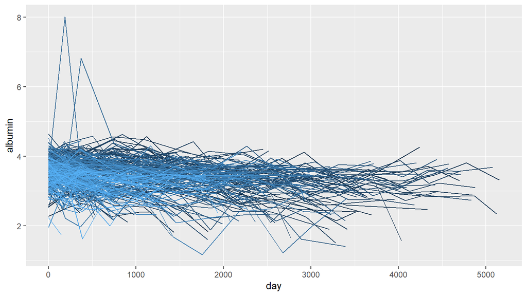

To analyse the trajectories of `albumin` we want to use the following linear mixed effects model with random intercept and slope (either using `lme` from the package **nlme** or using `lmer` from the package **lme4**):

```r
# using package nlme
lme(albumin ~ day + sex + trt + age + ascites + bili + copper, random = ~day|id)


# using package lme4
lmer(albumin ~ day + sex + trt + age + ascites + bili + copper + (day|id))
```

## Imputation using **mice**

For imputation of longitudinal data, the **mice** package provides special imputation methods that take into account the two-level structure of the data.

In the `pbclong` data, missing values occur in baseline covariates `ascites` and `copper`, and the time-varying variable `hepato`.

For imputation of baseline covariates, the imputation methods

- `2lonly.pmm` and
- `2lonly.norm`

are available.

Time-varying variables can be imputed with imputation methods such as `2l.norm` or `2l.bin`. Since the imputation of `hepato` with `2l.bin` takes quite some time, we will omit it in this part of the practical.

The `predictorMatrix` requires some extra specification to identify the “id” variable (set to -2) and the random effects structure (set to 2).

### Task 1

Run the setup imputation and perform the necessary changes in the imputation method and predictor matrix.

**mice** does not recognize automatically that the data are multil-level, hence the settings chosen by default are not correct. You need to specify imputation methods for all incomplete variables.

### Solution 1

```r
micelong0 <- mice(pbclong, maxit = 0)
meth_micelong <- micelong0$method
pred_micelong <- micelong0$predictorMatrix

# don't impute hepato
meth_micelong[c("hepato")] <- ""
# exclude hepato from predictor of other models (because incomplete)
pred_micelong[, c("hepato")] <- 0

meth_micelong[c("copper", "ascites")] <- "2lonly.pmm"

pred_micelong[, "id"] <- -2
pred_micelong[, "day"] <- 2


# check the imputation method
meth_micelong
```

```
##           id          trt          age          sex          day      ascites       hepato
##           ""           ""           ""           ""           "" "2lonly.pmm"           ""
##         bili      albumin       copper
##           ""           "" "2lonly.pmm"
```

```r
# check the predictor matrix
pred_micelong
```

```
##         id trt age sex day ascites hepato bili albumin copper
## id      -2   1   1   1   2       1      0    1       1      1
## trt     -2   0   1   1   2       1      0    1       1      1
## age     -2   1   0   1   2       1      0    1       1      1
## sex     -2   1   1   0   2       1      0    1       1      1
## day     -2   1   1   1   2       1      0    1       1      1
## ascites -2   1   1   1   2       0      0    1       1      1
## hepato  -2   1   1   1   2       1      0    1       1      1
## bili    -2   1   1   1   2       1      0    0       1      1
## albumin -2   1   1   1   2       1      0    1       0      1
## copper  -2   1   1   1   2       1      0    1       1      0
```

### Task 2

- run the imputation with the adapted imputation method `meth_micelong` and predictor matrix `pred_micelong`
- analyse the imputed data
- pool the results

### Solution 2

```r
micelong <- mice(pbclong, meth = meth_micelong, pred = pred_micelong,
                 maxit = 20, seed = 2019, printFlag = FALSE)

library(nlme)
micelong_mira <- with(micelong, lme(albumin ~ day + sex + trt + age + ascites +
                                      bili + copper, random = ~day|id)
)

# alternative:
# library(lme4)
# micelong_mira <- with(micelong, lmer(albumin ~ day + sex + trt + age + ascites +
#                                        bili + copper + (day|id))
# )

summary(pool(micelong_mira), conf.int = TRUE)
```

|  | estimate | std.error | statistic | df | p.value | 2.5 % | 97.5 % |
| --- | --- | --- | --- | --- | --- | --- | --- |
| (Intercept) | 4.1813859489 | 1.284455e-01 | 32.5537729 | 1166.19694 | 0.0000000000 | 3.9293758259 | 4.4333960720 |
| day | -0.0001945994 | 1.372037e-05 | -14.1832461 | 1522.58757 | 0.0000000000 | -0.0002215122 | -0.0001676866 |
| sexf | -0.1275357659 | 6.591413e-02 | -1.9348776 | 847.46629 | 0.0533377918 | -0.2569098493 | 0.0018383174 |
| trt | 0.0043356560 | 3.875721e-02 | 0.1118671 | 1563.42885 | 0.9109431574 | -0.0716859337 | 0.0803572458 |
| age | -0.0072616071 | 1.917443e-03 | -3.7871297 | 1471.11190 | 0.0001585338 | -0.0110228217 | -0.0035003924 |
| ascites1 | -0.2110892289 | 9.162741e-02 | -2.3037783 | 75.61726 | 0.0239837622 | -0.3935959610 | -0.0285824968 |
| bili | -0.0245219144 | 2.434075e-03 | -10.0744269 | 908.20437 | 0.0000000000 | -0.0292989807 | -0.0197448481 |
| copper | -0.0008350204 | 3.280988e-04 | -2.5450270 | 35.25996 | 0.0154552922 | -0.0015009209 | -0.0001691199 |

## Imputation using **JointAI**

To analyse incomplete longitudinal data using a linear mixed model the R package **JointAI** provides the function `lme_imp()`. The specification of the main model components is analogous to the function `lme()` from the **nlme** package.

**Specification of longitudinal models:**  
When imputing variables in a longitudinal (or other multi-level) model and there are missing values in baseline (level-2) covariates, models need to be specified for all longitudinal covariates, even if they do not have missing values. Specifying no model would imply that the incomplete baseline covariates are independent of the complete longitudinal variable (see also [here](https://nerler.github.io/JointAI/articles/ModelSpecification.html#why-do-we-need-models-for-completely-observed-longitudinal-covariates)). Therefore, **JointAI** automatically specifies models for all longitudinal covariates in such a setting.

An exception may be the time variable: it is often reasonable to assume that the baseline covariates are independent of the measurement times of the outcome and longitudinal covariates. To tell **JointAI** not to specify a model for the time variable, the argument `no_model` can be used.

**Model types for longitudinal covariates:**  
For longitudinal covariates the following model types are implemented:

| name | model | variable type |
| --- | --- | --- |
| `lmm` | linear mixed model | continuous variables |
| `glmm_logit` | logistic mixed model | factors with two levels |
| `glmm_gamma` | gamma mixed model (with log-link) | skewed continuous variables |
| `glmm_poisson` | poisson mixed model | count variables |
| `clmm` | cumulative logit mixed model | ordered factors with >2 levels |

**More info:**  
For the specification of the other arguments of `lme_imp()`, refer to

- the [help page](https://nerler.github.io/JointAI/reference/model_imp.html),
- the vignette on [Model Specification](https://nerler.github.io/JointAI/articles/ModelSpecification.html#MultiLevelStructure), or
- the details given in the practical on [Imputation with Non-linear Associations](https://nerler.github.io/EP16_Multiple_Imputation/practical/minonlin/MInonlin.html)

### Task

Run the imputation (start with `n.iter = 500`; this will take a few seconds).

### Solution

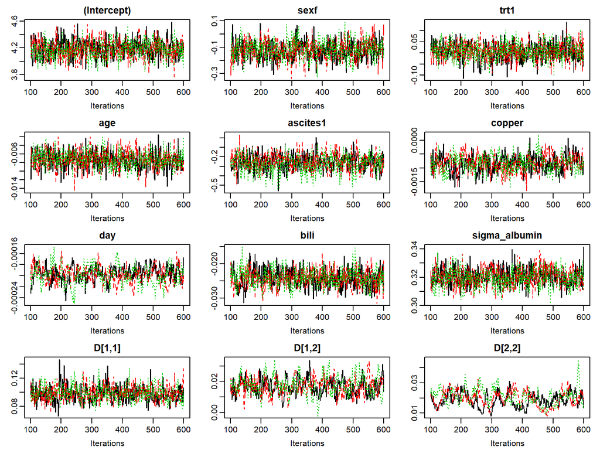

```
##
##  Linear mixed model fitted with JointAI
##
## Call:
## lme_imp(fixed = albumin ~ day + sex + trt + age + ascites + bili +
##     copper, data = pbclong, random = ~day | id, n.adapt = 100,
##     n.iter = 500, models = c(copper = "lognorm", bili = "glmm_gamma"),
##     no_model = "day", seed = 2019)
##
## Posterior summary:
##                  Mean       SD      2.5%     97.5% tail-prob. GR-crit
## (Intercept)  4.181810 1.26e-01  3.938326  4.432889    0.00000    1.02
## sexf        -0.120500 6.65e-02 -0.248397  0.012888    0.06933    1.02
## trt1         0.007132 3.71e-02 -0.064701  0.079317    0.85333    1.01
## age         -0.007328 1.89e-03 -0.010996 -0.003585    0.00000    1.00
## ascites1    -0.256927 8.51e-02 -0.427299 -0.093563    0.00267    1.09
## copper      -0.000841 2.93e-04 -0.001417 -0.000260    0.00400    1.01
## day         -0.000198 1.49e-05 -0.000228 -0.000169    0.00000    1.03
## bili        -0.024212 2.45e-03 -0.028824 -0.019362    0.00000    1.01
##
## Posterior summary of random effects covariance matrix:
##          Mean      SD    2.5%  97.5% tail-prob. GR-crit
## D[1,1] 0.0988 0.01040 0.08033 0.1202               1.02
## D[1,2] 0.0170 0.00547 0.00674 0.0285      0.004    1.04
## D[2,2] 0.0198 0.00504 0.01068 0.0297               1.18
##
## Posterior summary of residual std. deviation:
##               Mean      SD  2.5% 97.5% GR-crit
## sigma_albumin 0.32 0.00607 0.309 0.332    1.02
##
##
## MCMC settings:
## Iterations = 101:600
## Sample size per chain = 500
## Thinning interval = 1
## Number of chains = 3
##
## Number of observations: 1945
## Number of groups: 312
```

```r
library(JointAI)
JointAIlong <- lme_imp(albumin ~ day + sex + trt + age + ascites +
                         bili + copper, random = ~day|id,
                       models = c(copper = 'lognorm', bili = 'glmm_gamma'),
                       no_model = 'day', data = pbclong, n.iter = 500, seed = 2019)

traceplot(JointAIlong)
summary(JointAIlong)
```

## Additional exercise JointAI

We want to fit a logistic mixed model for the variable `hepato` and explore if the association is non-linear over time.

### Task 1

- Fit a logistic mixed model using the function `glme_imp` using the same covariates as before.
- Specify a natural cubic spline with 3 degrees of freedom for `day`.
- Check convergence using a `traceplot()`.

When specifying a generalized (mixed) model remember to specify the model family and link function.

To use natural cubic splines use the function `ns()` from the package **splines**, i.e., `ns(day, df = 3)`.

### Solution 1

```r
library(splines)
JointAIlong2 <- glme_imp(hepato ~ ns(day, df = 3) + sex + trt + age + ascites +
                           bili + copper, random = ~1|id, family = binomial(),
                         models = c(copper = 'lognorm', bili = 'glmm_gamma'),
                         no_model = 'day', data = pbclong, n.iter = 1000,
                         seed = 2019)

traceplot(JointAIlong2)
```

[output not shown]

### Task 2

When the model has converged, we want to visualize the potentially non-linear association of `day`. To do that, we can create a new dataset containing information on an “average” subject, with different values for `day`.

The function `predDF()` creates such a dataset from an object of class `JointAI`. It sets reference values (i.e., the median for continuous variables and the reference category for categorical variables) for all variables other than the one specified in the argument `var`. The variable given in `var` will range across the range of values of that variable encountered in the data.

Use `predDF()` to create a dataset that allows visualization of the effect of `day`.

### Solution 2

```r
newdf <- predDF(JointAIlong2, var = 'day')

head(newdf)
```

|  | hepato | day | sex | trt | age | ascites | bili | copper |
| --- | --- | --- | --- | --- | --- | --- | --- | --- |
| 1 | 0 | 0.0000 | m | 0 | 48.87064 | 0 | 1.4 | 64 |
| 2 | 0 | 52.0404 | m | 0 | 48.87064 | 0 | 1.4 | 64 |
| 3 | 0 | 104.0808 | m | 0 | 48.87064 | 0 | 1.4 | 64 |
| 4 | 0 | 156.1212 | m | 0 | 48.87064 | 0 | 1.4 | 64 |
| 5 | 0 | 208.1616 | m | 0 | 48.87064 | 0 | 1.4 | 64 |
| 6 | 0 | 260.2020 | m | 0 | 48.87064 | 0 | 1.4 | 64 |

### Task 3

We can now predict the outcome of our model for our “average” subject using the function `predict()`. It takes a `JointAI` object and a `data.frame` containing the data to predict from as arguments. The argument `quantiles` can be used to specify which quantiles of the distribution of each fitted value are returned (default is `2.5%` and `97.5%`).

`predict()` returns a list with the following elements

- `dat`: the `data.frame` provided by the user extended with the fitted values and 2.5% and 97.5% quantiles that form the credible interval for the fitted values
- `fit`: a vector containing the fitted values (the mean of the distribution of the fitted value)
- `quantiles`: a matrix containing the credible interval for each fitted value
- Use `predict()` to obtain the fitted values and corresponding intervals
- Visualize the result by plotting fitted values and quantiles (y-axis) over time (`day`; x-axis)

### Solution 3

```r
# pred <- predict(JointAIlong2, newdata = newdf)

# ggplot(pred$dat, aes(x = day, y = fit)) +
  # geom_ribbon(aes(ymin = `2.5%`, ymax = `97.5%`), alpha = 0.3) +
  # geom_line()
```

[output not shown]

**Note:**  
The fitted values and quantiles are on the scale of the linear predictor, i.e., obtained by multiplying the data in `newdf` ($\mathbf x$) with the samples of the posterior distribution of the parameters ($\boldsymbol \beta$).

For a logistic model it is more intuitive to present the fitted values on the probability scale.

$$\log\left(\frac{\pi}{1-\pi}\right) = \mathbf x^\top\boldsymbol\beta
\qquad \Rightarrow \pi = \frac{\exp(\mathbf x^\top\boldsymbol\beta)}{1 + \exp(\mathbf x^\top\boldsymbol\beta)}$$

The function `plogis()` does this transformation.

```r
# # ggplot(pred$dat, aes(x = day, y = plogis(fit))) +
#   geom_ribbon(aes(ymin = plogis(`2.5%`), ymax = plogis(`97.5%`)), alpha = 0.3) +
  # geom_line() +
  # ylab('probability of hepatomegaly')
```

[output not shown]

© Nicole Erler